# autoencoders-commented

```python
import numpy as np
import matplotlib.pyplot as plt
from sklearn.datasets import make_moons, load_digits
import torch.nn as nn
import torch
import torch.optim as optim
from torch.utils.data import DataLoader
from torchvision import transforms
from sklearn import mixture
```

## 1. Two-dimensional data with bottleneck

```python
epochs = 100
batch_size = 100

input_size = 2
bottleneck_size = 1
```

```python
class Autoencoder(nn.Module):
    def __init__(self, input_size = 2, \
                 bottleneck_size = 1,
                 hidden_size = 10, layers = 2):
        super(Autoencoder, self).__init__()
        # self.input_size = input_size
        # self.bottleneck_size = bottleneck_size
        # self.hidden_size = hidden_size
        # self.layers = layers
        encoder_mod = [
            nn.Linear(input_size, hidden_size),
            nn.ReLU(),
            ]
        decoder_mod = [
            nn.Linear(bottleneck_size, hidden_size),
            nn.ReLU(),
        ]
        for _ in range(layers):
            encoder_mod.append(nn.Linear(hidden_size,hidden_size))
            encoder_mod.append(nn.ReLU())
            decoder_mod.append(nn.Linear(hidden_size,hidden_size))
            decoder_mod.append(nn.ReLU())
        encoder_mod += [nn.Linear(hidden_size, bottleneck_size), nn.ReLU()]
        decoder_mod += [nn.Linear(hidden_size, input_size)]
        self.encoder = nn.Sequential(*encoder_mod)
        self.decoder = nn.Sequential(*decoder_mod)

    def forward(self, x):
        x = self.encoder(x)
        x = self.decoder(x)
        return x

    def fit(self, train_loader, epochs = 100):
        criterion = nn.MSELoss()
        optimizer = optim.Adam(self.parameters(), lr=0.001)
        for epoch in range(epochs):
            running_loss = 0.0
            for data in train_loader:
                inputs = data.float()
                optimizer.zero_grad()
                outputs = self(inputs)
                loss = criterion(outputs, inputs)
                loss.backward()
                optimizer.step()
                running_loss += loss.item()
            # print('Epoch: %d, loss: %.3f' % (epoch + 1, running_loss / len(train_loader)))
```

### 1. Determine the best hyperparameters

```python
# hyperparameters: hidden_size, layers
hidden_size_list = [10, 20, 30, 40, 50]
layers_list = [2, 5, 10, 15, 20]
training_points_list = [1000, 3000]

# initialize the result dictionary
result = {}
```

```python
# train the autoencoder with different hyperparameters
for training_points in training_points_list:
    for hidden_size in hidden_size_list:
        for layers in layers_list:
            X, _ = make_moons(n_samples=training_points, noise=0.1)
            autoencoder = Autoencoder(input_size = input_size, \
                            bottleneck_size = bottleneck_size,
                            hidden_size = hidden_size, layers = layers)
            loss = nn.MSELoss()
            train_loader = DataLoader(dataset = torch.from_numpy(X), batch_size = batch_size, shuffle = True)
            autoencoder.fit(train_loader, epochs = epochs)
            # record the loss of the autoencoder
            X_test, _ = make_moons(n_samples=1000, noise=0.1)
            result[(training_points, hidden_size, layers)] = loss(autoencoder(torch.from_numpy(X_test).float()), torch.from_numpy(X_test).float()).item()
            print("training_points: %d, hidden_size: %d, layers: %d" % (training_points, hidden_size, layers))
```

```
training_points: 1000, hidden_size: 10, layers: 2
training_points: 1000, hidden_size: 10, layers: 5
training_points: 1000, hidden_size: 10, layers: 10
training_points: 1000, hidden_size: 10, layers: 15
training_points: 1000, hidden_size: 10, layers: 20
training_points: 1000, hidden_size: 20, layers: 2
training_points: 1000, hidden_size: 20, layers: 5
training_points: 1000, hidden_size: 20, layers: 10
training_points: 1000, hidden_size: 20, layers: 15
training_points: 1000, hidden_size: 20, layers: 20
training_points: 1000, hidden_size: 30, layers: 2
training_points: 1000, hidden_size: 30, layers: 5
training_points: 1000, hidden_size: 30, layers: 10
training_points: 1000, hidden_size: 30, layers: 15
training_points: 1000, hidden_size: 30, layers: 20
training_points: 1000, hidden_size: 40, layers: 2
training_points: 1000, hidden_size: 40, layers: 5
training_points: 1000, hidden_size: 40, layers: 10
training_points: 1000, hidden_size: 40, layers: 15
training_points: 1000, hidden_size: 40, layers: 20
training_points: 1000, hidden_size: 50, layers: 2
training_points: 1000, hidden_size: 50, layers: 5
training_points: 1000, hidden_size: 50, layers: 10
training_points: 1000, hidden_size: 50, layers: 15
training_points: 1000, hidden_size: 50, layers: 20
training_points: 3000, hidden_size: 10, layers: 2
training_points: 3000, hidden_size: 10, layers: 5
training_points: 3000, hidden_size: 10, layers: 10
training_points: 3000, hidden_size: 10, layers: 15
training_points: 3000, hidden_size: 10, layers: 20
training_points: 3000, hidden_size: 20, layers: 2
training_points: 3000, hidden_size: 20, layers: 5
training_points: 3000, hidden_size: 20, layers: 10
training_points: 3000, hidden_size: 20, layers: 15
training_points: 3000, hidden_size: 20, layers: 20
training_points: 3000, hidden_size: 30, layers: 2
training_points: 3000, hidden_size: 30, layers: 5
training_points: 3000, hidden_size: 30, layers: 10
training_points: 3000, hidden_size: 30, layers: 15
training_points: 3000, hidden_size: 30, layers: 20
training_points: 3000, hidden_size: 40, layers: 2
training_points: 3000, hidden_size: 40, layers: 5
training_points: 3000, hidden_size: 40, layers: 10
training_points: 3000, hidden_size: 40, layers: 15
training_points: 3000, hidden_size: 40, layers: 20
training_points: 3000, hidden_size: 50, layers: 2
training_points: 3000, hidden_size: 50, layers: 5
training_points: 3000, hidden_size: 50, layers: 10
training_points: 3000, hidden_size: 50, layers: 15
training_points: 3000, hidden_size: 50, layers: 20
```

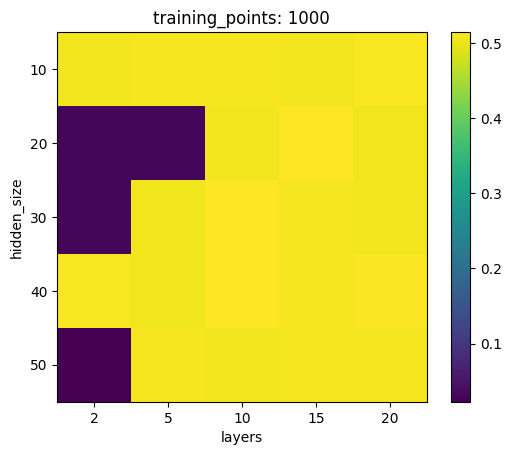

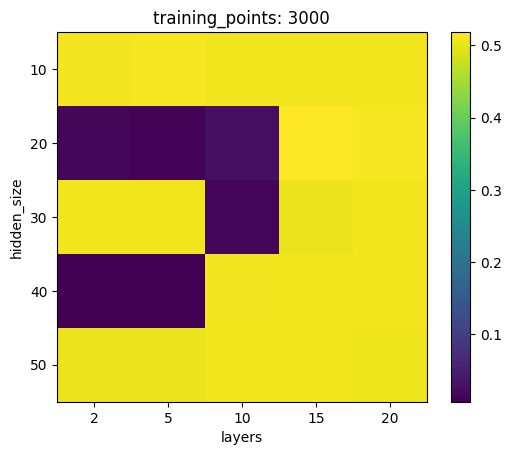

```python
# plot the loss of the autoencoder with two heatmaps
for training_points in training_points_list:
    loss_list = []
    for hidden_size in hidden_size_list:
        loss_list.append([result[(training_points, hidden_size, layers)] for layers in layers_list])
    plt.figure()
    plt.imshow(loss_list)
    plt.colorbar()
    plt.title("training_points: %d" % training_points)
    plt.xlabel("layers")
    plt.ylabel("hidden_size")
    plt.xticks(np.arange(len(layers_list)), layers_list)
    plt.yticks(np.arange(len(hidden_size_list)), hidden_size_list)
    plt.savefig("training_points_%d.png" % training_points)
    plt.show()
```

Comment: The code is essentially correct, but the experiments we did were not performed as the working example did to check the effect of each hyperparameter. We did not visualize the effect of each hyperparameter with a reconstruction plot. But we also find the optimal hidden units should be around 20 and optimal layers should be 5.

### 2. Continue training with the different datasets and investigate how much the reconstruction varies

```python
hidden_size = 20
layers = 5
bottleneck_size = 1
# satisfactory performance with: hidden size = 20 layers = 5
```

```python
X, _ = make_moons(n_samples=2000, noise=0.1)
autoencoder = Autoencoder(input_size = input_size, \
                 bottleneck_size = bottleneck_size,
                 hidden_size = hidden_size, layers = layers)
train_loader = DataLoader(dataset = torch.from_numpy(X), batch_size = batch_size, shuffle = True)
optimizer = optim.Adam(autoencoder.parameters())
```

```
Epoch [1/100], Loss: 0.5300
Epoch [11/100], Loss: 0.1197
Epoch [21/100], Loss: 0.0556
Epoch [31/100], Loss: 0.0362
Epoch [41/100], Loss: 0.0351
Epoch [51/100], Loss: 0.0247
Epoch [61/100], Loss: 0.0199
Epoch [71/100], Loss: 0.0260
Epoch [81/100], Loss: 0.0201
Epoch [91/100], Loss: 0.0148
```

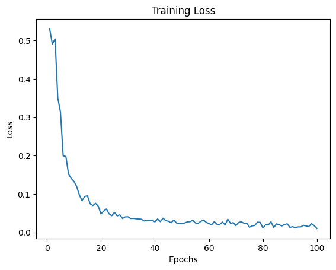

```python
# create a directory to save the loss_val
loss_list = []
epochs_list = []

for epoch in range(epochs):
    for data in train_loader:
        inputs = data.float()
        optimizer.zero_grad()
        outputs = autoencoder(inputs)
        loss_val = loss(outputs, inputs)
        loss_val.backward()
        optimizer.step()
    loss_list.append(loss_val.item())
    epochs_list.append(epoch+1)
    if epoch % 10 == 0:
        print(f'Epoch [{epoch+1}/{epochs}], Loss: {loss_val.item():.4f}')

# Plotting the training loss
plt.plot(epochs_list, loss_list)
plt.xlabel("Epochs")
plt.ylabel("Loss")
plt.title("Training Loss")
```

Sometimes the loss decreases in a stable speed, while at certain times the loss does not decrease at all when the size of the neural network becomes too large.

But sometimes, the loss will not decrease and fluctate at a high level. Then the output of the decoder will shrink to a single point.

Comment: The code is essentially correct, but what we could improve is that we could visualize the reconstruction data repetitively.

```python
# visualize effect of autoencoder
def plot_images(original, reconstructed):
    for i in range(len(original)):
        # print(original[i].numpy())
        plt.scatter(original[i].numpy()[0],original[i].numpy()[1], \
                    c = '#1f77b4')
        plt.scatter(reconstructed[i].numpy()[0], \
                    reconstructed[i].numpy()[1], c = '#ff7f0e')
    plt.show()
```

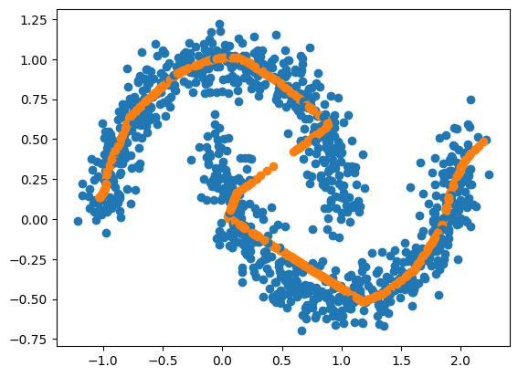

```python
with torch.no_grad():
    test_data, _ = make_moons(n_samples=1000, noise=0.1)
    test_data = torch.from_numpy(test_data).float()
    recon_data = autoencoder(test_data)
    plot_images(test_data, recon_data)
```

```python
def histogram(X, BINS, visualize = False):
    # Create a 2D histogram
    hist, x_edges, y_edges = np.histogram2d(X[:, 0], X[:, 1], bins=BINS)
    # reserve the pdf for later use
    pdf = hist / hist.sum()
    if visualize:# Visualize the histogram
        plt.imshow(pdf, interpolation='nearest', origin='lower', extent=[x_edges[0], x_edges[-1], y_edges[0], y_edges[-1]])
        plt.colorbar()
        plt.show()
    return pdf
```

```python
# sample uniformly from the space
sample_temp_x = torch.from_numpy(np.random.uniform(
    low = [-1.5,-1],
    high = [2.5, 2],
    size = (1000,2))).float()
sample_temp_x = autoencoder(sample_temp_x).detach().numpy()
```

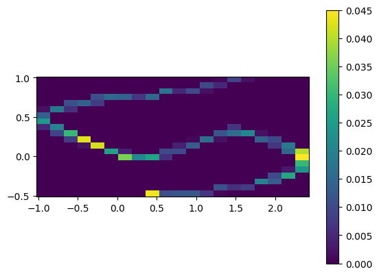

```python
hist = histogram(sample_temp_x, 20, visualize = True)
```

```python
# fit GMM to the code dist.
class GMM():
    def __init__(self, n_components = 2, covariance_type = 'full'):
        self.n_components = n_components
        self.covariance_type = covariance_type

    def fit(self, data, visualize = False):
        self.gmm = mixture.GaussianMixture(n_components=self.n_components, covariance_type='full')
        self.gmm.fit(data)
        if visualize:
            plt.scatter(data[:,0], data[:,1], c = self.gmm.predict(data))
            plt.show()

    def sample(self, n_samples = 1):
        return self.gmm.sample(n_samples = n_samples)[0]
```

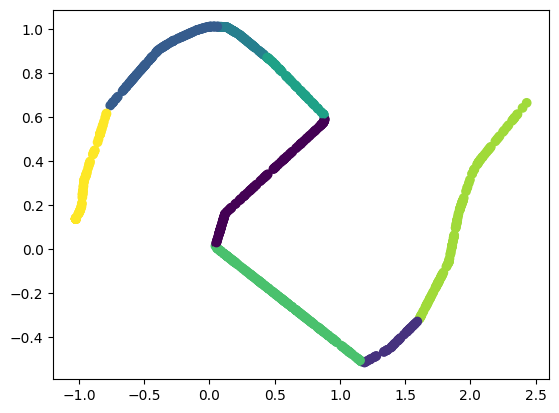

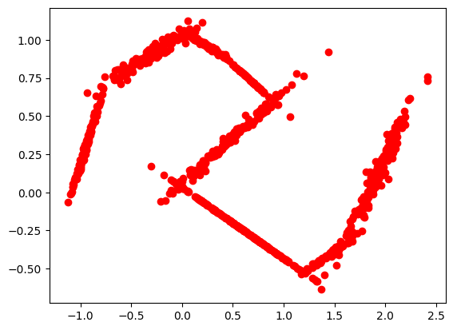

```python
# fit GMM to the code dist.
gmm = GMM(n_components = 8)
gmm.fit(sample_temp_x, visualize = True)
sample_temp_x_gmm = gmm.sample(1000)

# visualize the effect of GMM
plt.scatter(sample_temp_x_gmm[:,0], sample_temp_x_gmm[:,1], c = 'r')
```

When we choose n_components = 8 The generated data of GMM based on the synthetic data is not bad, since we could see two moons inside.

Comment: What we did wrong is that we take the output of encoder-decoder as the code distribution by mistake. We should have used the encoder output as the fit data of GMM to generate new code samples.

### 4. Check if the autoencoder still works on noise level 0.2

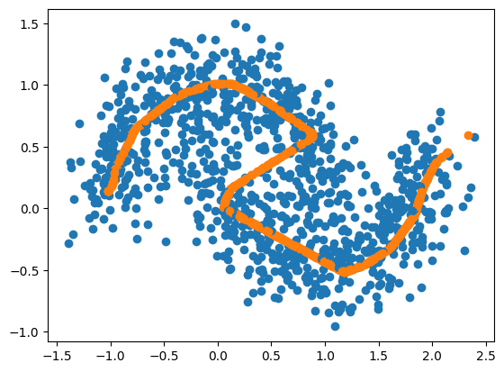

```python
# noise level 0.2
with torch.no_grad():
    test_data, _ = make_moons(n_samples=1000, noise=0.2)
    test_data = torch.from_numpy(test_data).float()
    recon_data = autoencoder(test_data)
    plot_images(test_data, recon_data)
```

The plot shows that the autoencoder still works on the new test set.

Comment: The code is essentially correct.

### 5. Retrain the autoencoder with a training set at a noise level 0.2

```python
# noise level 0.2: retraining
X_2, _ = make_moons(n_samples=2000, noise=0.2)
autoencoder_2 = Autoencoder(input_size = input_size, \
                 bottleneck_size = bottleneck_size,
                 hidden_size = 20, layers = layers)
loss = nn.MSELoss()
train_loader = DataLoader(dataset = X_2, batch_size = batch_size, shuffle = True)
autoencoder_2.fit(train_loader, epochs = epochs)
```

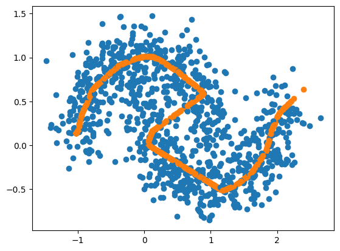

```python
with torch.no_grad():
    test_data, _ = make_moons(n_samples=1000, noise=0.2)
    test_data = torch.from_numpy(test_data).float()
    recon_data = autoencoder(test_data)
    plot_images(test_data, recon_data)
```

Comment: The code is essentially correct, but our training results are more robust around the centerlines.

## 2. Two-dimensional data without bottleneck

```python
# implement the MMD metric with squared exponential kernel and inverse multiquadric kernel
def squared_exponential_kernel(x, y, h = 1):
    return np.exp(-np.linalg.norm(x-y)**2/(2*h))

def inverse_multiquadric_kernel(x, y, h = 1):
    return 1/np.sqrt(np.linalg.norm(x-y)**2 / h + 1)

def MMD2(X, Y, kernel_type, h):
    # X, Y: numpy array
    # return: scalar
    n = len(X)
    m = len(Y)
    if kernel_type == 'squared_exponential':
        kernel = squared_exponential_kernel
    elif kernel_type == 'inverse_multiquadric':
        kernel = inverse_multiquadric_kernel
    else:
        raise ValueError('kernel_type must be squared_exponential or inverse_multiquadric')
    K_XX = np.zeros((n, n))
    K_XY = np.zeros((n, m))
    K_YY = np.zeros((m, m))
    for i in range(n):
        for j in range(n):
            K_XX[i, j] = kernel(X[i], X[j], h)
    for i in range(n):
        for j in range(m):
            K_XY[i, j] = kernel(X[i], Y[j], h)
    for i in range(m):
        for j in range(m):
            K_YY[i, j] = kernel(Y[i], Y[j], h)
    return 1/(n*(n-1)) * np.sum(K_XX) - 2/(n*m) * np.sum(K_XY) + 1/(m*(m-1)) * np.sum(K_YY)

# add MMD loss to the L2 loss
def MMD_loss(X, Y, kernel_type, h, alpha):
    # X, Y: numpy array
    # alpha: weight of MMD loss
    # return: scalar
    loss = nn.MSELoss()
    return loss(X, Y) + alpha * MMD2(X.detach().numpy(), Y.detach().numpy(), kernel_type, h)
```

```
Epoch [1/100], Loss: 0.8943
Epoch [11/100], Loss: 0.1567
Epoch [21/100], Loss: 0.0526
Epoch [31/100], Loss: 0.0534
Epoch [41/100], Loss: 0.0482
Epoch [51/100], Loss: 0.0531
Epoch [61/100], Loss: 0.0472
Epoch [71/100], Loss: 0.0411
Epoch [81/100], Loss: 0.0519
Epoch [91/100], Loss: 0.0169
```

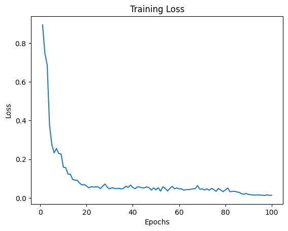

```
Epoch [1/100], Loss: 0.8495
Epoch [11/100], Loss: 0.1095
Epoch [21/100], Loss: 0.0801
Epoch [31/100], Loss: 0.0581
Epoch [41/100], Loss: 0.0180
Epoch [51/100], Loss: 0.0137
Epoch [61/100], Loss: 0.0140
Epoch [71/100], Loss: 0.0136
Epoch [81/100], Loss: 0.0133
Epoch [91/100], Loss: 0.0134
```

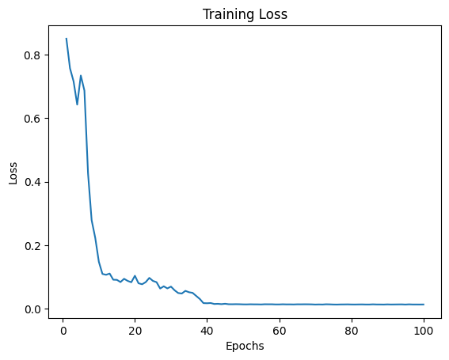

```python
# bottleneck size 2 and add Maximum mean discrepancy (MMD) loss to the L2 loss
autoencoder2 = Autoencoder(input_size = input_size, \
                  bottleneck_size = 2,
                  hidden_size = 20, layers = 5)
optimizer = optim.Adam(autoencoder2.parameters())

# train the model at noise level 0.1
epochs = 100

X, _ = make_moons(n_samples=2500, noise=0.1)

# define a new function to train the model
def train_mmd_autoencoder(autoencoder, X, epochs = 100, alpha = 1, kernel_type = 'squared_exponential', h = 1, visualize = False):
    optimizer = optim.Adam(autoencoder.parameters())
    train_loader = DataLoader(dataset = X, batch_size = batch_size, shuffle = True)
    loss_list = []
    epochs_list = []
    for epoch in range(epochs):
        for data in train_loader:
            inputs = data.float()
            optimizer.zero_grad()
            outputs = autoencoder(inputs)
            loss_val = MMD_loss(outputs, inputs, kernel_type, h, alpha)
            loss_val.backward()
            optimizer.step()
        loss_list.append(loss_val.item())
        epochs_list.append(epoch+1)
        if epoch % 10 == 0:
            print(f'Epoch [{epoch+1}/{epochs}], Loss: {loss_val.item():.4f}')
    # visualize the loss of training
    if visualize:
        plt.plot(epochs_list, loss_list)
        plt.xlabel("Epochs")
        plt.ylabel("Loss")
        plt.title("Training Loss")
        plt.show()
    return autoencoder

autoencoder2_se = train_mmd_autoencoder(autoencoder2, X, epochs = epochs, alpha = 1, kernel_type = 'squared_exponential', h = 1, visualize = True)


autoencoder2 = Autoencoder(input_size = input_size, \
                  bottleneck_size = 2,
                  hidden_size = 20, layers = 5)
optimizer = optim.Adam(autoencoder2.parameters())

autoencoder2_im = train_mmd_autoencoder(autoencoder2, X, epochs = epochs, alpha = 1, kernel_type = 'inverse_multiquadric', h = 1, visualize = True)
```

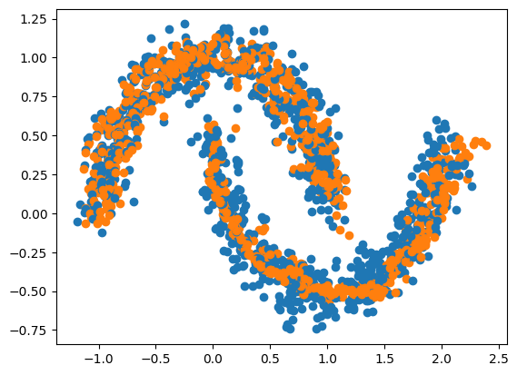

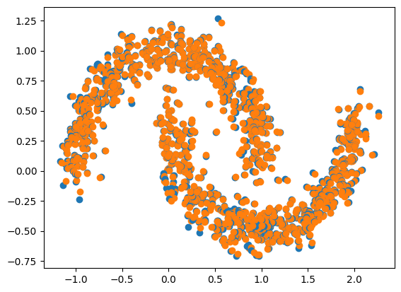

```python
# visualize the effect of autoencoder_se and autoencoder_im
with torch.no_grad():
    test_data, _ = make_moons(n_samples=1000, noise=0.1)
    test_data = torch.from_numpy(test_data).float()
    recon_data = autoencoder2_se(test_data)
    plot_images(test_data, recon_data)

with torch.no_grad():
    test_data, _ = make_moons(n_samples=1000, noise=0.1)
    test_data = torch.from_numpy(test_data).float()
    recon_data = autoencoder2_im(test_data)
    plot_images(test_data, recon_data)
```

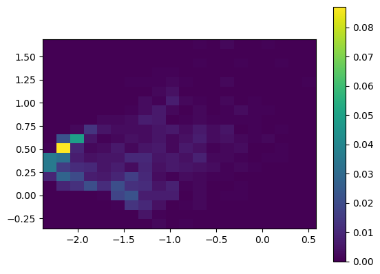

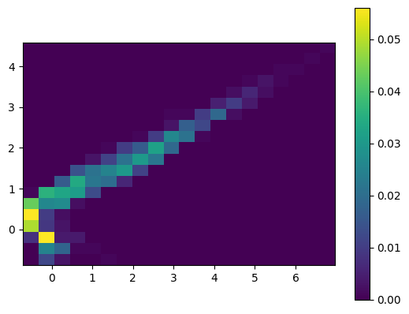

```python
# sample from standard normal distribution with mu
sample_temp_x = torch.from_numpy(np.random.normal(
    loc = 0,
    scale = 1,
    size = (1000,2))).float()

# pass the sample through the decoder
sample_temp_x_se = autoencoder2_se.decoder(sample_temp_x).detach().numpy()

hist = histogram(sample_temp_x_se, 20, visualize = True)

sample_temp_x_im = autoencoder2_im.decoder(sample_temp_x).detach().numpy()

hist = histogram(sample_temp_x_im, 20, visualize = True)
```

The reconstruction error of the autoencoder is obviously much less than what we got with a bottleneck of size 1.

Comment: The code is essentially correct. The same problem as before is that we did not use the correct code distribution. We did not use the different bandwidths and take the average as the MMD loss, while we tried different kernels.

## 3 Higher-dimensional data

```python
X = load_digits().data
input_size = 64
hidden_size = 128
layers = 5

loss = nn.MSELoss()
train_loader = DataLoader(dataset = torch.from_numpy(X), batch_size = batch_size, shuffle = True)
```

```python
loss_values = []

epochs = 50
bottleneck_size_list = [2, 4, 8]
layers_list = [2, 4, 6, 10]
hidden_size_list = [16, 32, 64, 128]

# initialize the result dictionary
result = {}

# train the autoencoder with different hyperparameters
for bottleneck_size in bottleneck_size_list:
    for layers in layers_list:
        for hidden_size in hidden_size_list:
            autoencoder = Autoencoder(input_size = input_size, \
                            bottleneck_size = bottleneck_size,
                            hidden_size = hidden_size, layers = layers)
            optimizer = optim.Adam(autoencoder.parameters())
            autoencoder.fit(train_loader, epochs = epochs)
            # record the loss of the autoencoder
            X_test = load_digits().data
            result[(bottleneck_size, layers, hidden_size)] = loss(autoencoder(torch.from_numpy(X_test).float()), torch.from_numpy(X_test).float()).item()
            print("bottleneck_size: %d, layers: %d, hidden_size: %d, loss: %d" % (bottleneck_size, layers, hidden_size, result[(bottleneck_size, layers, hidden_size)]))
```

```
bottleneck_size: 2, layers: 2, hidden_size: 16, loss: 18
bottleneck_size: 2, layers: 2, hidden_size: 32, loss: 18
bottleneck_size: 2, layers: 2, hidden_size: 64, loss: 18
bottleneck_size: 2, layers: 2, hidden_size: 128, loss: 18
bottleneck_size: 2, layers: 4, hidden_size: 16, loss: 18
bottleneck_size: 2, layers: 4, hidden_size: 32, loss: 18
bottleneck_size: 2, layers: 4, hidden_size: 64, loss: 18
bottleneck_size: 2, layers: 4, hidden_size: 128, loss: 18
bottleneck_size: 2, layers: 6, hidden_size: 16, loss: 18
bottleneck_size: 2, layers: 6, hidden_size: 32, loss: 18
bottleneck_size: 2, layers: 6, hidden_size: 64, loss: 18
bottleneck_size: 2, layers: 6, hidden_size: 128, loss: 18
bottleneck_size: 2, layers: 10, hidden_size: 16, loss: 18
bottleneck_size: 2, layers: 10, hidden_size: 32, loss: 18
bottleneck_size: 2, layers: 10, hidden_size: 64, loss: 18
bottleneck_size: 2, layers: 10, hidden_size: 128, loss: 18
bottleneck_size: 4, layers: 2, hidden_size: 16, loss: 15
bottleneck_size: 4, layers: 2, hidden_size: 32, loss: 18
bottleneck_size: 4, layers: 2, hidden_size: 64, loss: 13
bottleneck_size: 4, layers: 2, hidden_size: 128, loss: 18
bottleneck_size: 4, layers: 4, hidden_size: 16, loss: 18
bottleneck_size: 4, layers: 4, hidden_size: 32, loss: 18
bottleneck_size: 4, layers: 4, hidden_size: 64, loss: 18
bottleneck_size: 4, layers: 4, hidden_size: 128, loss: 18
bottleneck_size: 4, layers: 6, hidden_size: 16, loss: 18
bottleneck_size: 4, layers: 6, hidden_size: 32, loss: 18
bottleneck_size: 4, layers: 6, hidden_size: 64, loss: 18
bottleneck_size: 4, layers: 6, hidden_size: 128, loss: 18
bottleneck_size: 4, layers: 10, hidden_size: 16, loss: 18
bottleneck_size: 4, layers: 10, hidden_size: 32, loss: 18
bottleneck_size: 4, layers: 10, hidden_size: 64, loss: 18
bottleneck_size: 4, layers: 10, hidden_size: 128, loss: 18
bottleneck_size: 8, layers: 2, hidden_size: 16, loss: 15
bottleneck_size: 8, layers: 2, hidden_size: 32, loss: 13
bottleneck_size: 8, layers: 2, hidden_size: 64, loss: 9
bottleneck_size: 8, layers: 2, hidden_size: 128, loss: 8
bottleneck_size: 8, layers: 4, hidden_size: 16, loss: 18
bottleneck_size: 8, layers: 4, hidden_size: 32, loss: 18
bottleneck_size: 8, layers: 4, hidden_size: 64, loss: 18
bottleneck_size: 8, layers: 4, hidden_size: 128, loss: 18
bottleneck_size: 8, layers: 6, hidden_size: 16, loss: 18
bottleneck_size: 8, layers: 6, hidden_size: 32, loss: 18
bottleneck_size: 8, layers: 6, hidden_size: 64, loss: 18
bottleneck_size: 8, layers: 6, hidden_size: 128, loss: 18
bottleneck_size: 8, layers: 10, hidden_size: 16, loss: 18
bottleneck_size: 8, layers: 10, hidden_size: 32, loss: 18
bottleneck_size: 8, layers: 10, hidden_size: 64, loss: 18
bottleneck_size: 8, layers: 10, hidden_size: 128, loss: 18
```

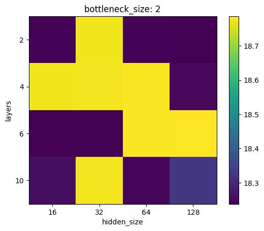

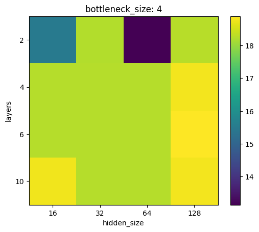

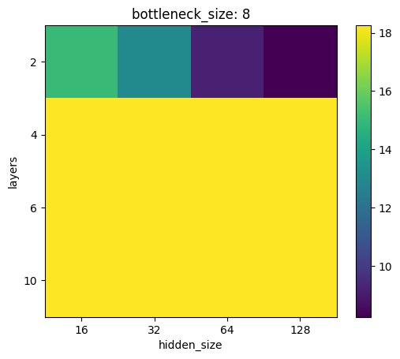

```python
# plot the loss of the autoencoder with three heatmaps

for bottleneck_size in bottleneck_size_list:
    loss_list = []
    for layers in layers_list:
        loss_list.append([result[(bottleneck_size, layers, hidden_size)] for hidden_size in hidden_size_list])
    plt.figure()
    plt.imshow(loss_list)
    plt.colorbar()
    plt.title("bottleneck_size: %d" % bottleneck_size)
    plt.xlabel("hidden_size")
    plt.ylabel("layers")
    plt.xticks(np.arange(len(hidden_size_list)), hidden_size_list)
    plt.yticks(np.arange(len(layers_list)), layers_list)
    # plt.savefig("bottleneck_size_%d.png" % bottleneck_size)
    plt.show()
```

Then we will choose layers = 2, hidden_size = 128 and the bottleneck_size = 8.

```python
# train networks with bottleneck size 2, 4, 8
layers = 2
hidden_size = 128
epochs = 50

autoencoder2 = Autoencoder(input_size = input_size, \
                        bottleneck_size = 2,
                        hidden_size = hidden_size, layers = layers)

autoencoder4 = Autoencoder(input_size = input_size, \
                        bottleneck_size = 4,
                        hidden_size = hidden_size, layers = layers)

autoencoder8 = Autoencoder(input_size = input_size, \
                        bottleneck_size = 8,
                        hidden_size = hidden_size, layers = layers)

for autoencoder in [autoencoder8, autoencoder4, autoencoder8]:
    optimizer = optim.Adam(autoencoder.parameters())
    autoencoder.fit(train_loader, epochs = epochs)
```

```
tensor([-7.5816e-02,  1.3185e-01,  7.8064e+00,  3.8843e+00, -2.8107e+00,
        -1.8752e+00, -1.1670e+00, -3.4019e-01, -1.8182e-02,  1.8067e+00,
         1.4100e+01, -3.5560e+00, -6.6396e+00,  5.7030e+00,  7.4703e-01,
        -2.5819e-01, -7.1454e-02,  3.7047e+00,  1.0227e+01, -1.3409e+01,
        -1.4425e+01,  6.7221e+00,  4.4063e+00, -3.8645e-01, -6.7473e-02,
         2.7449e+00,  6.2792e+00, -1.6083e+01, -1.7815e+01,  5.9673e+00,
         9.1003e+00,  1.9789e-02, -5.1272e-02,  6.5309e+00,  8.1354e+00,
        -1.3894e+01, -1.8224e+01,  5.8366e+00,  7.0943e+00, -2.2002e-02,
         1.0007e-01,  4.0835e+00,  8.4049e+00, -1.4911e+01, -1.5707e+01,
         7.1803e+00,  4.2436e+00, -2.9037e-01,  8.0891e-02,  1.1527e+00,
         1.2252e+01, -7.6062e+00, -4.1760e+00,  6.9212e+00, -2.4724e-01,
        -3.0635e-01,  1.1818e-01,  7.6330e-02,  7.2011e+00,  5.6229e+00,
        -3.5960e+00, -7.0140e+00, -3.7943e+00, -1.1506e+00])
tensor([-4.2031e-02,  9.6583e-02,  5.8625e+00,  1.3314e+01,  1.1552e+01,
         3.2387e+00, -1.9367e-01, -7.7116e-02,  1.1836e-01,  9.8556e-01,
         1.3365e+01,  1.1474e+01,  1.0321e+01,  1.1539e+01,  1.0024e+00,
        -1.6436e-01,  6.5422e-02,  3.5587e+00,  1.3138e+01,  2.9507e+00,
         1.9303e+00,  1.1335e+01,  4.2227e+00,  1.0529e-02, -3.9765e-02,
         5.5807e+00,  1.2128e+01,  4.6139e-01, -4.7094e-01,  8.3797e+00,
         6.5613e+00, -3.1205e-02,  2.4797e-02,  6.4550e+00,  1.1714e+01,
         3.9056e-01, -5.4481e-01,  8.5201e+00,  6.6718e+00, -1.2330e-01,
        -6.0849e-03,  4.1921e+00,  1.1917e+01,  9.9182e-02,  1.0535e+00,
         1.1996e+01,  4.6805e+00, -7.5252e-02,  6.6616e-02,  1.1722e+00,
         1.3503e+01,  7.6918e+00,  1.1263e+01,  1.2581e+01,  2.8459e-01,
        -6.9438e-02,  2.3208e-02, -1.2334e-01,  5.8175e+00,  1.3945e+01,
         1.1934e+01,  2.0283e+00, -9.0660e-01,  4.0345e-01])
tensor([ 3.3785e-02, -3.5269e-02, -1.9440e+00,  9.4297e+00,  1.4362e+01,
         5.1140e+00,  9.7329e-01,  2.6307e-01,  1.3654e-01, -8.2112e-01,
        -7.3552e-01,  1.5030e+01,  1.6960e+01,  5.8356e+00,  2.5537e-01,
         9.3824e-02,  1.3688e-01, -1.4600e-01,  2.9107e+00,  1.6359e+01,
         1.6355e+01,  4.6128e+00, -1.8358e-01,  3.9698e-01,  2.7708e-02,
         2.8358e+00,  5.8490e+00,  1.6544e+01,  1.7344e+01,  2.4124e+00,
        -2.5389e+00, -5.0995e-02,  7.6068e-02, -7.5873e-02,  3.5785e+00,
         1.4285e+01,  1.7679e+01,  2.6835e+00, -4.2250e-01, -1.0130e-01,
        -1.0616e-01,  1.0860e-01,  3.5118e+00,  1.5010e+01,  1.6760e+01,
         4.8162e+00,  4.3687e-01,  2.1512e-01, -1.4275e-02,  1.9523e-02,
         1.2502e+00,  1.5298e+01,  1.5439e+01,  5.6598e+00,  5.3183e-01,
         2.3691e-01, -9.4973e-02, -1.9967e-01, -1.3835e+00,  8.3218e+00,
         1.5530e+01,  9.0423e+00,  2.8877e+00,  1.5541e+00])
```

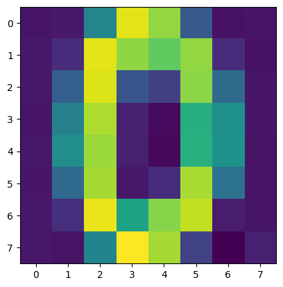

```python
# reconstruct some digits:
with torch.no_grad():
    test_data = load_digits().data
    test_data = torch.from_numpy(test_data).float()
    recon_data = autoencoder8(test_data)
    print(recon_data[0]-recon_data[1])
    print(recon_data[0])
    print(recon_data[1])
    plt.imshow(recon_data[0].reshape(8,8))
```

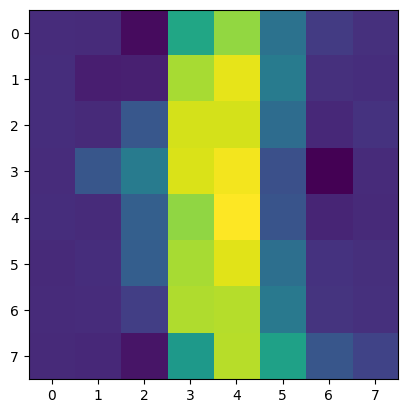

```python
# quality of reconstruction as a function of bottleneck size
# can one recognize the labels in reconstruction?
#
plt.imshow(recon_data[1].reshape(8,8))
```

```python
# train a random forest classifier based on the training data
from sklearn.ensemble import RandomForestClassifier
from sklearn.model_selection import train_test_split

X = load_digits().data
y = load_digits().target

X_train, X_test, y_train, y_test = train_test_split(X, y, test_size=0.2)

clf = RandomForestClassifier(max_depth=2, random_state=0)
clf.fit(X_train, y_train)
clf.score(X_test, y_test)

# use the classifier to predict the labels of the reconstructed digits
recon_data = autoencoder8(torch.from_numpy(X_test).float()).detach().numpy()
clf.predict(recon_data)

# check the accuracy of the classifier
clf.score(recon_data, y_test)
```

```
0.7333333333333333
```

Comment: The code is essentially correct. The same problem as before is that we did not use the correct code distribution. We should have compared the average accuracy of each architecture under random forest.